# AE1

## 1. Loading and Preprocessing Text

```python
import pandas as pd

# (i) Load the Data
df = pd.read_csv('/Users/sergiughimp/Desktop/Uni_UK/IntermediateProgrammingwithData/AE1_vishing_data_zipped.csv.zip',
                  engine='python')
df.head(5)
```

|  | created_at | id | source | author_id | lang | text |
| --- | --- | --- | --- | --- | --- | --- |
| 0 | 2019-04-01T10:12:52.000Z | 21TUSlvC | Twitter for iPhone | PnsVIF3t | en | Is there any scam calls going round now where ... |
| 1 | 2019-04-01T10:09:41.000Z | RAirKQbc | Twitter for iPhone | 0qttFPpb | in | RT @NerdKid_94: Hi rakan2...\n\nAku almost ken... |
| 2 | 2019-04-01T10:07:27.000Z | qYUxZ2mt | Twitter for Android | jvz5kV7T | in | RT @NerdKid_94: Hi rakan2...\n\nAku almost ken... |
| 3 | 2019-04-01T10:07:01.000Z | wF60bOz6 | Twitter Web Client | ueO4OFLj | en | Yet another scam call allegedly from @bt_uk ab... |
| 4 | 2019-04-01T10:04:21.000Z | SaUph6W6 | Twitter Web App | UjoJU61H | in | RT @NerdKid_94: Hi rakan2...\n\nAku almost ken... |

```python
import re
import pandas as pd

# Preprocessing function
def preprocess_text(text):
    '''
    Preprocesses text by:
        (i) converting it to lowercase,
        (ii) removing special characters,
        (iii) removing digits,
        (iv) removing redundant whitespace,
        (v) converting it to a list of words
        (vi) excluding meaningless words (removing words with only one character or less).
    Args:
        text (str): Original AE1_vishing_data_zipped text.
    Returns:
        list: List of processed words

    '''

    if text is None:
        return []

    text = text.lower()  # Step (i)
    text = re.sub(r'[^a-zA-Z\s]', '', text)  # Step (ii)
    text = re.sub(r'\d+', '', text)  # Step (iii)
    text = re.sub(r'\s+', ' ', text).strip()  # Step (iv)
    words = text.split()  # Step (v)
    filtered_words = [word for word in words if len(word) > 1]  # Step (vi)

    return filtered_words

# Apply preprocessing
df['processed_text'] = df['text'].apply(preprocess_text)

# Display the result
print(df['processed_text'].head(10))
```

```
0    [is, there, any, scam, calls, going, round, no...
1    [rt, nerdkid, hi, rakan, aku, almost, kena, sc...
2    [rt, nerdkid, hi, rakan, aku, almost, kena, sc...
3    [yet, another, scam, call, allegedly, from, bt...
4    [rt, nerdkid, hi, rakan, aku, almost, kena, sc...
5    [scam, alert, beware, of, scammers, impersonat...
6    [do, you, know, the, difference, between, phis...
7    [hi, rakan, aku, almost, kena, scam, via, phon...
8    [frontpoint, can, you, guys, explain, how, it,...
9    [amazonhelp, need, help, received, call, from,...
Name: processed_text, dtype: object
```

## 2. Analysing Text

```python
from collections import Counter

# (i) Count the frequency of words
all_words = [word for text in df['processed_text'] for word in text]
word_counts = Counter(all_words)

# Get the top 10 frequent words
top_10_words = word_counts.most_common(10)

# Display top 10 words
print("Top 10 Frequent Words:", top_10_words)
```

```
Top 10 Frequent Words: [('call', 1209675), ('to', 967235), ('scam', 964332), ('rt', 904313), ('the', 882568), ('you', 591192), ('and', 574649), ('is', 460647), ('of', 405386), ('for', 319496)]
```

```python
# (ii) Vocabulary richness (unique words / total words)
total_words = len(all_words)
unique_words = len(set(all_words))
vocabulary_richness = unique_words / total_words if total_words != 0 else 0

# Display vocabulary richness
print("Vocabulary Richness:", vocabulary_richness)
```

```
Vocabulary Richness: 0.0208941553624895
```

```python
# (iii) Identify common words between users
top_users = df['author_id'].value_counts().head(10).index

# Create a dictionary to store words for each user
user_words = {user: [] for user in top_users}

for idx, row in df.iterrows():
    if row['author_id'] in top_users:
        user_words[row['author_id']] += row['processed_text']

# Find common words between users
common_words = {user: set(words) for user, words in user_words.items()}

# Find intersection of words between all top users
common_between_all = set.intersection(*common_words.values()) if common_words else set()

# Display the common words across all users
print("Common Words Across All Top Users:", common_between_all)

# Display the common words for each user:
# for user, words in common_words.items():
#     print(f"Common words for {user}: \n {words}")
```

```
Common Words Across All Top Users: {'to', 'call'}
```

## 3. Visualising Data

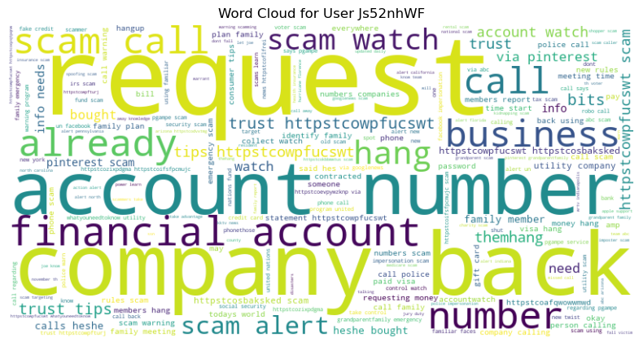

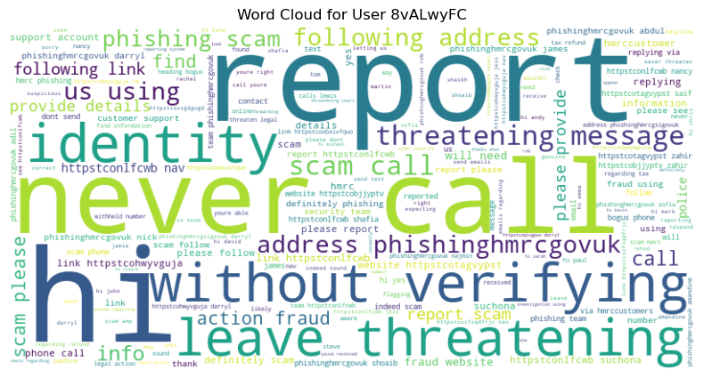

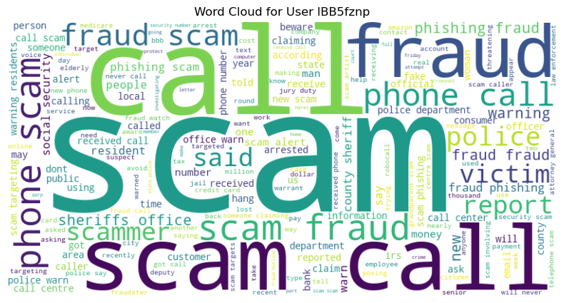

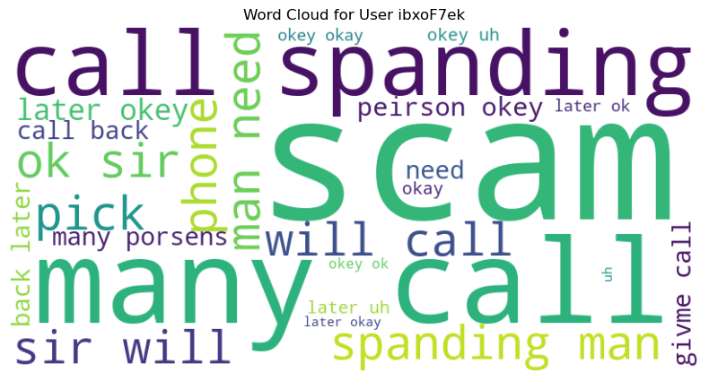

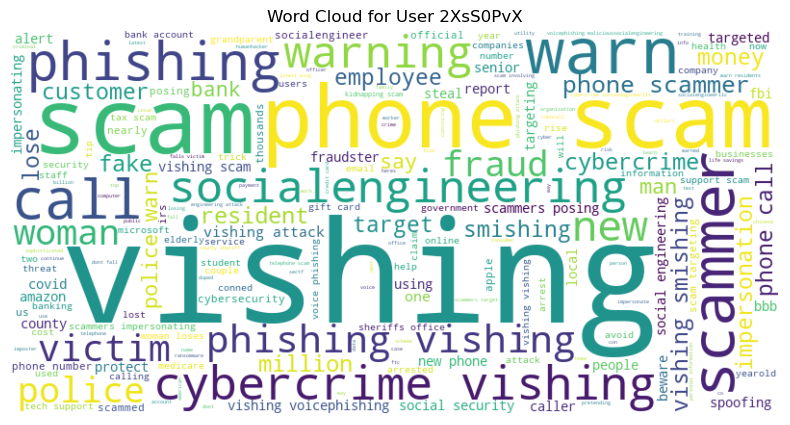

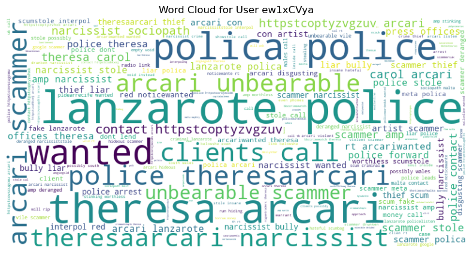

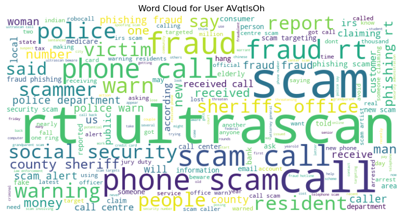

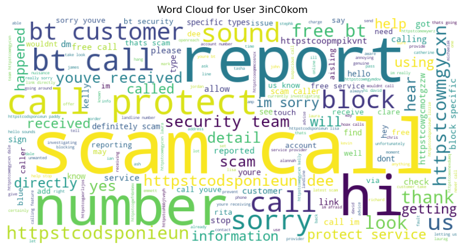

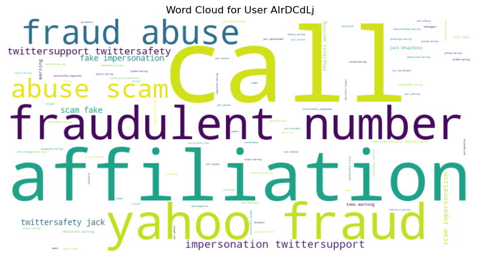

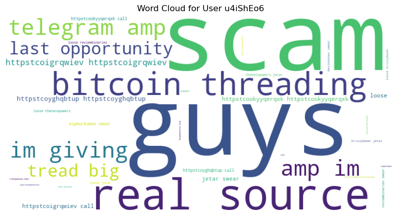

```python
# (i) generating word clouds for top 10 users

import matplotlib.pyplot as plt
from wordcloud import WordCloud

# Generate word clouds for the top 10 users
for user in top_users:
    if user in user_words and user_words[user]:  # Ensure user has words
        user_text = ' '.join(user_words[user])  # Combine all words into a single string
        wordcloud = WordCloud(width=800, height=400, background_color='white').generate(user_text)

        # Plot the word cloud
        plt.figure(figsize=(10, 5))
        plt.imshow(wordcloud, interpolation='bilinear')
        plt.axis("off")
        plt.title(f"Word Cloud for User {user}")
        plt.show()
```

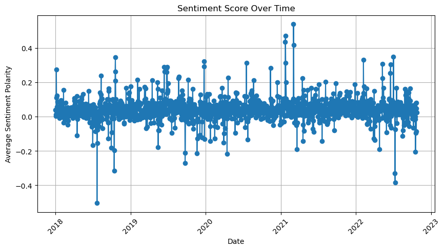

```python
# (ii) compute the sentiment scores of those users and plot them overtime.

import pandas as pd
from textblob import TextBlob
import matplotlib.pyplot as plt

# Convert to datetime format, handling errors
df["tweet_created"] = pd.to_datetime(df["created_at"], errors='coerce')

# Drop rows where conversion failed
df = df.dropna(subset=["tweet_created"])

# Create date column safely using .loc
df.loc[:, "date"] = df["tweet_created"].dt.date

# Function to compute sentiment polarity
def compute_sentiment(text):
    """
    Computes the sentiment polarity of the given text using TextBlob.

    Args:
        text (str): Tweet text.

    Returns:
        float: Sentiment polarity score.
    """
    return TextBlob(str(text)).sentiment.polarity  # Convert to string to handle NaN cases

# Apply sentiment function
df["polarity"] = df["text"].apply(compute_sentiment)

# Group by date and compute average sentiment
grouped = df.groupby(['date'])['polarity'].mean().reset_index()

# Plot sentiment over time
plt.figure(figsize=(10, 5))
plt.plot(grouped["date"], grouped["polarity"], marker="o", linestyle="-")
plt.xlabel("Date")
plt.ylabel("Average Sentiment Polarity")
plt.title("Sentiment Score Over Time")
plt.xticks(rotation=45)
plt.grid()
plt.show()
```

## 4. Visualising N-grams

```python
import pandas as pd
import matplotlib.pyplot as plt
from collections import Counter
from textblob import TextBlob

# Step 1: Convert created_at to datetime format and create date column
df["created_at"] = pd.to_datetime(df["created_at"], errors='coerce')
df["date"] = df["created_at"].dt.date

# Step 2: Generate n-grams function (1-gram to 4-gram)
def ngrams_generator(df_processed_text, n):
    # Flatten the list of lists and combine all text entries into a single string
    combined_text = " ".join([word for sublist in df_processed_text.dropna() for word in sublist])

    # Tokenize the text: split by whitespace
    words = combined_text.split()

    # Generate n-grams using zip
    ngrams = zip(*[words[i:] for i in range(n)])

    # Concatenate tokens in each n-gram to form a string
    return [" ".join(ngram) for ngram in ngrams]

# Step 3: Generate n-grams for unigrams (1), bigrams (2), trigrams (3), and quadgrams (4) using the function
unigrams = ngrams_generator(df["processed_text"], 1)
bigrams = ngrams_generator(df["processed_text"], 2)
trigrams = ngrams_generator(df["processed_text"], 3)
quadgrams = ngrams_generator(df["processed_text"], 4)

# Step 4: Count frequency of n-grams using Counter
unigram_counts = Counter(unigrams)
bigram_counts = Counter(bigrams)
trigram_counts = Counter(trigrams)
quadgram_counts = Counter(quadgrams)

# Step 5: Get top 5 most common n-grams for each category
top_5_unigrams = unigram_counts.most_common(5)
top_5_bigrams = bigram_counts.most_common(5)
top_5_trigrams = trigram_counts.most_common(5)
top_5_quadgrams = quadgram_counts.most_common(5)

# Print Top N-grams
print("Top 5 Unigrams:")
for phrase, count in top_5_unigrams:
    print(f"{phrase}: {count}")

print("\nTop 5 Bigrams:")
for phrase, count in top_5_bigrams:
    print(f"{phrase}: {count}")

print("\nTop 5 Trigrams:")
for phrase, count in top_5_trigrams:
    print(f"{phrase}: {count}")

print("\nTop 5 Quadgrams:")
for phrase, count in top_5_quadgrams:
    print(f"{phrase}: {count}")
```

```
Top 5 Unigrams:
call: 1209675
to: 967235
scam: 964332
rt: 904313
the: 882568

Top 5 Bigrams:
to call: 117813
scam call: 113874
if you: 112523
call from: 105005
to be: 101167

Top 5 Trigrams:
is scam dont: 39742
just move on: 39300
closure is scam: 39255
to be from: 38797
claiming to be: 38244

Top 5 Quadgrams:
closure is scam dont: 39174
call just move on: 36454
dont call just move: 36423
text dont call just: 36413
is scam dont text: 36368
```

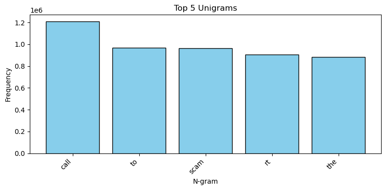

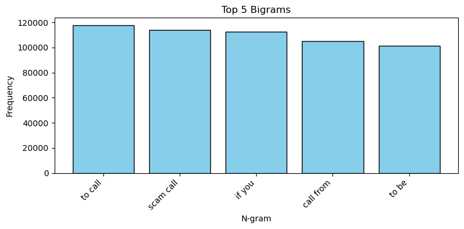

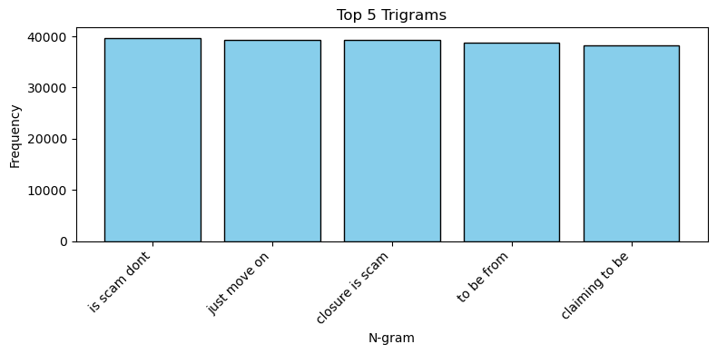

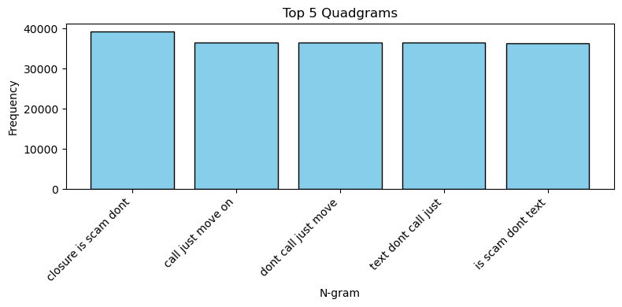

```python
# Visualization: Plot the top N n-grams (unigrams, bigrams, trigrams, quadgrams)
def plot_top_ngrams(ngram_counts, title):
    ngrams, counts = zip(*ngram_counts)
    plt.figure(figsize=(8, 4))
    plt.bar(ngrams, counts, color="skyblue", edgecolor="black")
    plt.title(title)
    plt.xlabel("N-gram")
    plt.ylabel("Frequency")
    plt.xticks(rotation=45, ha="right")
    plt.tight_layout()
    plt.show()

# Plot for unigrams, bigrams, trigrams, and quadgrams
plot_top_ngrams(top_5_unigrams, "Top 5 Unigrams")
plot_top_ngrams(top_5_bigrams, "Top 5 Bigrams")
plot_top_ngrams(top_5_trigrams, "Top 5 Trigrams")
plot_top_ngrams(top_5_quadgrams, "Top 5 Quadgrams")
```

## 5. Reflecting on the Process

**AE2 – Individual Report**

**Methods**

In this project, various data analysis techniques were employed to extract valuable insights from a text-based dataset. The first key step was text preprocessing, which cleaned and standardized the raw text. This included converting text to lowercase, removing special characters, digits, redundant whitespace, and filtering out meaningless words. This ensured that the data was clean and ready for further analysis, eliminating unnecessary noise.

Next, word frequency analysis was conducted using Python's Counter from the collections module. This allowed for the identification of the most common words across the dataset, offering insights into frequently discussed topics. Alongside this, vocabulary richness was calculated by dividing the number of unique words by the total number of words. A higher vocabulary richness score indicated a diverse range of language use, while a lower score suggested repetitive language.

To understand the emotional tone of the content, sentiment analysis was performed using the TextBlob library. The sentiment polarity scores ranged from negative to positive, and the results were visualized over time, highlighting how user sentiment evolved. This method provided insights into user feelings and reactions to various topics.

Finally, n-gram analysis was used to uncover common word sequences, such as unigrams, bigrams, trigrams, and quadgrams. This method identified frequently occurring phrases and word patterns that could have been overlooked in a simpler word frequency analysis. The top n-grams were visualized in bar charts, allowing for easy comparison and highlighting the most relevant multi-word expressions.

In summary, the project utilized a combination of preprocessing, word frequency analysis, sentiment analysis, and n-gram generation to uncover patterns, sentiments, and themes within the dataset. These methods provided a comprehensive understanding of the content, user behavior, and emotional trends, making them invaluable tools for text mining and analysis.

**Results**

The analysis of the AE1_vishing dataset revealed key insights into the text data, with a focus on identifying frequent themes and user behaviors. Text preprocessing helped clean the data, removing noise and ensuring a more accurate analysis. Word frequency analysis highlighted the most common terms, shedding light on central topics and trends. Additionally, vocabulary richness showed how diverse the language was, providing a measure of engagement within the content.

The sentiment analysis tracked changes in user emotions over time, offering valuable insights into public opinion. By identifying common words among top users and generating word clouds, we gained a clearer understanding of user interests and the topics they discussed. Finally, n-gram analysis uncovered common phrases, revealing deeper patterns in the dataset.

These findings are valuable for understanding user behavior, content engagement, and sentiment, and can guide strategies in areas like marketing, content creation, and community management.

**Conclusion**

Through this project, I have gained valuable insights into user interactions and sentiment trends. By carefully processing and analyzing the text data, I identified recurring themes, popular phrases, and shifts in emotions over time. These results provide actionable insights for improving content strategies and better understanding what drives user engagement. While there are some limitations, such as missing data and potential biases, I made sure to handle these factors ethically throughout the process. Ultimately, the findings offer businesses and organizations a clearer understanding of their audience, enabling them to make smarter, data-driven decisions for more effective engagement and content creation.

**Lessons Learned and Future Improvements**

Throughout this project, I gained valuable experience in text preprocessing, sentiment analysis, and pattern recognition. Cleaning and transforming the text data taught me how to effectively manage inconsistent or noisy information. Identifying frequent words and phrases allowed me to understand how to extract meaningful insights from raw content. Analyzing sentiment over time provided a deeper understanding of how user emotions evolve, which is crucial for improving engagement strategies. Looking ahead, I plan to refine my analysis by exploring more advanced techniques, such as topic modeling and deeper sentiment analysis. I also aim to automate parts of the data preprocessing process and experiment with more sophisticated visualizations. This project has enhanced my analytical skills and provided a strong foundation for future data-driven projects.

**Difficulty I Had:**

Throughout this project, I faced a few specific challenges that helped me refine my problem-solving skills.

One of the main difficulties was dealing with the need to use lists instead of just text for preprocessing the data. Initially, I was focused on handling raw text, but since the preprocessing involved multiple steps like tokenizing and removing unwanted characters, I had to switch to using lists to store and process words efficiently. This added complexity, as it required me to adapt my approach to handle the data in a structured way.

Another challenge I encountered was when creating the date column. I needed to use a method to safely assign values to the new column. This method was necessary to avoid errors related to setting values in a specific column while ensuring the datetime conversion was handled properly. Although it took a bit of time to understand the correct usage, I managed to overcome this obstacle and ensure that the data was formatted correctly.

Additionally, when generating the combined text for further analysis, I had to flatten the list of lists to prepare the text for analysis. Although it was tricky to manage the nested lists, I was able to successfully join the text, which allowed for more efficient analysis.

Despite these challenges, I gained valuable experience in handling data in more structured ways and improved my ability to use Pandas efficiently.

**How I Overcame This Difficulty:**

During the project, I faced a few challenges, but I was able to find solutions that helped me move forward and learn along the way.

One challenge was working with lists instead of just using text to clean the data. At first, it felt difficult to handle the data this way, but I broke the task into smaller steps. I focused on cleaning the text, turning it into individual words, and removing unnecessary characters like numbers and special symbols. Once I put these words in lists, it became easier to work with and process the data.

Another challenge was creating a new date column from the existing datetime values in the dataset. I had to make sure the dates were converted properly. To do this, I used the .loc function, which helped me safely create the new column without messing up the rest of the data. This allowed me to have the dates in the right format for further work.

The last challenge was dealing with a list of lists when analyzing the text. It was tricky to combine all the words into one list, but I used a simple method to join the words together. This helped me look at all the words in the dataset as a whole and made it easier to find common words and phrases.

By solving these challenges one at a time, I was able to complete the project and improve my skills in data cleaning and analysis.